# E-Commerce Flipkart Revenue Management

```python
# Load the necessary libraries.
import numpy as np
import pandas as pd
import matplotlib.pyplot as plt
import seaborn as sns
```

```python
#Import and load the dataset with a name ECom_Data
ECom_Data=pd.read_csv(r"C:\Users\shiva\OneDrive\Desktop\Python data files\E-Commerce_Flipkart.csv")
ECom_Data
```

|  | Customer_uniq_id | Region | Order_Date | Expected_Delivery_Date | Delivered_Date | product_name | product_main_category | product_subcategory | product_category_filter | product_category_subfilter | product_unique ID | retail_price | discounted_price | product_rating | Brand | product_specifications | description |
| --- | --- | --- | --- | --- | --- | --- | --- | --- | --- | --- | --- | --- | --- | --- | --- | --- | --- |
| 0 | c2d766ca982eca8304150849735ffef9 | North | 31-12-2021 | 03-01-2022 | 02-01-2022 | Alisha Solid Women's Cycling Shorts | Clothing | Women's Clothing | Lingerie, Sleep & Swimwear | Shorts | SRTEH2FF9KEDEFGF | 999 | 379 | 2.0 | Alisha | {"product_specification"=>[{"key"=>"Number of ... | Key Features of Alisha Solid Women's Cycling S... |
| 1 | 7f7036a6d550aaa89d34c77bd39a5e48 | East | 31-12-2021 | 03-01-2022 | 02-01-2022 | FabHomeDecor Fabric Double Sofa Bed | Furniture | Living Room Furniture | Sofa Beds & Futons | FabHomeDecor Fabric Double Sofa Bed (Finish C... | SBEEH3QGU7MFYJFY | 32157 | 22646 | 2.0 | FabHomeDecor | {"product_specification"=>[{"key"=>"Installati... | FabHomeDecor Fabric Double Sofa Bed (Finish Co... |
| 2 | f449ec65dcbc041b6ae5e6a32717d01b | East | 31-12-2021 | 03-01-2022 | 02-01-2022 | AW Bellies | Footwear | Women's Footwear | Ballerinas | AW Bellies | SHOEH4GRSUBJGZXE | 999 | 499 | 1.0 | AW | {"product_specification"=>[{"key"=>"Ideal For"... | Key Features of AW Bellies Sandals Wedges Heel... |
| 3 | 0973b37acd0c664e3de26e97e5571454 | West | 31-12-2021 | 03-01-2022 | 02-01-2022 | Alisha Solid Women's Cycling Shorts | Clothing | Women's Clothing | Lingerie, Sleep & Swimwear | Shorts | SRTEH2F6HUZMQ6SJ | 699 | 267 | 5.0 | Alisha | {"product_specification"=>[{"key"=>"Number of ... | Key Features of Alisha Solid Women's Cycling S... |
| 4 | bc940ea42ee6bef5ac7cea3fb5cfbee7 | West | 31-12-2021 | 03-01-2022 | 02-01-2022 | Sicons All Purpose Arnica Dog Shampoo | Pet Supplies | Grooming | Skin & Coat Care | Shampoo | PSOEH3ZYDMSYARJ5 | 220 | 210 | 5.0 | Sicons | {"product_specification"=>[{"key"=>"Pet Type",... | Specifications of Sicons All Purpose Arnica Do... |
| ... | ... | ... | ... | ... | ... | ... | ... | ... | ... | ... | ... | ... | ... | ... | ... | ... | ... |
| 8922 | 90d30478255e23621e8929ed15c2f6e4 | South | 01-12-2020 | 04-12-2020 | 04-12-2020 | Sinina Chanderi Embroidered Salwar Suit Dupatt... | Clothing | Women's Clothing | Ethnic Wear | Fabric | FABEGGHHDFMY8BZU | 2980 | 1490 | 3.0 | Sinina | {"product_specification"=>[{"key"=>"Fabric", "... | Key Features of Sinina Chanderi Embroidered Sa... |
| 8923 | 20a73e3f41490a73ceeba5f17658db8f | West | 01-12-2020 | 04-12-2020 | 04-12-2020 | Aarushi Fashion Chanderi Embroidered Salwar Su... | Clothing | Women's Clothing | Ethnic Wear | Fabric | FABEG8GFDUWRSNU3 | 2600 | 1300 | 1.0 | Aarushi Fashion | {"product_specification"=>[{"key"=>"Fabric", "... | Key Features of Aarushi Fashion Chanderi Embro... |
| 8924 | 5c1554cd45f9d538c2c6947dbdd59c75 | East | 01-12-2020 | 04-12-2020 | 04-12-2020 | Ambika Lahenga Embroidered Lehenga, Choli and ... | Clothing | Women's Clothing | Ethnic Wear | Lehenga Cholis | LEHEGGEHYN4G2RPW | 39992 | 24995 | 1.0 | Ambika Lahenga | {"product_specification"=>[{"key"=>"Fabric", "... | Key Features of Ambika Lahenga Embroidered Leh... |
| 8925 | 6b737a4deca1ed0e56c179e66036e994 | West | 01-12-2020 | 04-12-2020 | 04-12-2020 | Sinina Chanderi Embroidered Salwar Suit Dupatt... | Clothing | Women's Clothing | Ethnic Wear | Fabric | FABEGGHHGSVCHGFV | 2000 | 1000 | 3.0 | Sinina | {"product_specification"=>[{"key"=>"Fabric", "... | Key Features of Sinina Chanderi Embroidered Sa... |
| 8926 | a5235ac28d3d5487f54025f9d6b57433 | North | 01-12-2020 | 04-12-2020 | 04-12-2020 | Aarushi Fashion Silk Striped Salwar Suit Dupat... | Clothing | Women's Clothing | Ethnic Wear | Fabric | FABEG8GYDAABECZH | 2800 | 1350 | 4.0 | Aarushi Fashion | {"product_specification"=>[{"key"=>"Fabric", "... | Key Features of Aarushi Fashion Silk Striped S... |

8927 rows × 17 columns

### Q 1. To get familiar with the data

```
a) Print out the first 10 and the last 10 records of the data.
b) How many rows and columns are present in the dataset? Use any two different methods to extract this information.
c) How many object data types are there?
d) Is there any Boolean data type?
```

```python
ECom_Data.head(10)
```

|  | Customer_uniq_id | Region | Order_Date | Expected_Delivery_Date | Delivered_Date | product_name | product_main_category | product_subcategory | product_category_filter | product_category_subfilter | product_unique ID | retail_price | discounted_price | product_rating | Brand | product_specifications | description |
| --- | --- | --- | --- | --- | --- | --- | --- | --- | --- | --- | --- | --- | --- | --- | --- | --- | --- |
| 0 | c2d766ca982eca8304150849735ffef9 | North | 31-12-2021 | 03-01-2022 | 02-01-2022 | Alisha Solid Women's Cycling Shorts | Clothing | Women's Clothing | Lingerie, Sleep & Swimwear | Shorts | SRTEH2FF9KEDEFGF | 999 | 379 | 2.0 | Alisha | {"product_specification"=>[{"key"=>"Number of ... | Key Features of Alisha Solid Women's Cycling S... |
| 1 | 7f7036a6d550aaa89d34c77bd39a5e48 | East | 31-12-2021 | 03-01-2022 | 02-01-2022 | FabHomeDecor Fabric Double Sofa Bed | Furniture | Living Room Furniture | Sofa Beds & Futons | FabHomeDecor Fabric Double Sofa Bed (Finish C... | SBEEH3QGU7MFYJFY | 32157 | 22646 | 2.0 | FabHomeDecor | {"product_specification"=>[{"key"=>"Installati... | FabHomeDecor Fabric Double Sofa Bed (Finish Co... |
| 2 | f449ec65dcbc041b6ae5e6a32717d01b | East | 31-12-2021 | 03-01-2022 | 02-01-2022 | AW Bellies | Footwear | Women's Footwear | Ballerinas | AW Bellies | SHOEH4GRSUBJGZXE | 999 | 499 | 1.0 | AW | {"product_specification"=>[{"key"=>"Ideal For"... | Key Features of AW Bellies Sandals Wedges Heel... |
| 3 | 0973b37acd0c664e3de26e97e5571454 | West | 31-12-2021 | 03-01-2022 | 02-01-2022 | Alisha Solid Women's Cycling Shorts | Clothing | Women's Clothing | Lingerie, Sleep & Swimwear | Shorts | SRTEH2F6HUZMQ6SJ | 699 | 267 | 5.0 | Alisha | {"product_specification"=>[{"key"=>"Number of ... | Key Features of Alisha Solid Women's Cycling S... |
| 4 | bc940ea42ee6bef5ac7cea3fb5cfbee7 | West | 31-12-2021 | 03-01-2022 | 02-01-2022 | Sicons All Purpose Arnica Dog Shampoo | Pet Supplies | Grooming | Skin & Coat Care | Shampoo | PSOEH3ZYDMSYARJ5 | 220 | 210 | 5.0 | Sicons | {"product_specification"=>[{"key"=>"Pet Type",... | Specifications of Sicons All Purpose Arnica Do... |
| 5 | ce5a6818f7707e2cb61fdcdbba61f5ad | East | 25-12-2021 | 28-12-2021 | 27-12-2021 | Alisha Solid Women's Cycling Shorts | Clothing | Women's Clothing | Lingerie, Sleep & Swimwear | Shorts | SRTEH2FVVKRBAXHB | 1199 | 479 | 4.0 | Alisha | {"product_specification"=>[{"key"=>"Number of ... | Key Features of Alisha Solid Women's Cycling S... |
| 6 | 8542703ca9e6ebdf6d742638dfb1f2ca | East | 25-12-2021 | 28-12-2021 | 27-12-2021 | FabHomeDecor Fabric Double Sofa Bed | Furniture | Living Room Furniture | Sofa Beds & Futons | FabHomeDecor Fabric Double Sofa Bed (Finish C... | SBEEH3QGYGHFUEXN | 32157 | 22646 | 2.0 | FabHomeDecor | {"product_specification"=>[{"key"=>"Installati... | FabHomeDecor Fabric Double Sofa Bed (Finish Co... |
| 7 | 29c8d290caa451f97b1c32df64477a2c | North | 25-12-2021 | 28-12-2021 | 27-12-2021 | dilli bazaaar Bellies, Corporate Casuals, Casuals | Footwear | Women's Footwear | Ballerinas | dilli bazaaar Bellies, Corporate Casuals, Cas... | SHOEH3DZBFR88SCK | 699 | 349 | 5.0 | dilli bazaaar | {"product_specification"=>[{"key"=>"Occasion",... | Key Features of dilli bazaaar Bellies, Corpora... |
| 8 | 4044c0ac52c1ee4b28777417651faf42 | East | 25-12-2021 | 28-12-2021 | 27-12-2021 | Alisha Solid Women's Cycling Shorts | Clothing | Women's Clothing | Lingerie, Sleep & Swimwear | Shorts | SRTEH2FVUHAAVH9X | 1199 | 479 | 1.0 | Alisha | {"product_specification"=>[{"key"=>"Number of ... | Key Features of Alisha Solid Women's Cycling S... |
| 9 | e54bc0a7c3429da2ebef0b30331fe3d2 | East | 25-12-2021 | 28-12-2021 | 27-12-2021 | Ladela Bellies | Footwear | Women's Footwear | Ballerinas | Ladela Bellies | SHOEH4KM2W3Z6EH5 | 1724 | 950 | 5.0 | Ladela | {"product_specification"=>[{"key"=>"Occasion",... | Key Features of Ladela Bellies Brand: LADELA C... |

### Ans 1 a) Explanation:The first 10 records of the data can be found using the function head().

### Result: The above data is showing the first 10 records of the data given

```python
ECom_Data.tail(10)
```

|  | Customer_uniq_id | Region | Order_Date | Expected_Delivery_Date | Delivered_Date | product_name | product_main_category | product_subcategory | product_category_filter | product_category_subfilter | product_unique ID | retail_price | discounted_price | product_rating | Brand | product_specifications | description |
| --- | --- | --- | --- | --- | --- | --- | --- | --- | --- | --- | --- | --- | --- | --- | --- | --- | --- |
| 8917 | 4db03bc4ccbe216cf151b2f2b904ba3f | East | 01-12-2020 | 04-12-2020 | 04-12-2020 | Luca Fashion Girls Heels | Footwear | Kids' & Infant Footwear | For Girls | Sandals | SNDEHG3DNVBFGAT5 | 999 | 499 | 4.0 | Luca Fashion | {"product_specification"=>[{"key"=>"Occasion",... | Key Features of Luca Fashion Girls Heels Occas... |
| 8918 | 4d4d6aeb13fa253499d0dd45a5abd87e | West | 01-12-2020 | 04-12-2020 | 04-12-2020 | Shoetopia Girls Sandals | Footwear | Kids' & Infant Footwear | For Girls | Sandals | SNDEG7DRWSX8HFXZ | 499 | 399 | 4.0 | Shoetopia | {"product_specification"=>[{"key"=>"Ideal For"... | Key Features of Shoetopia Girls Sandals Flats ... |
| 8919 | ea19e7ef703293d3f6c799ca9db4642d | West | 01-12-2020 | 04-12-2020 | 04-12-2020 | SMART TRADERS Girls Sandals | Footwear | Kids' & Infant Footwear | For Girls | Sandals | SNDEG7MZHHKZ58D2 | 999 | 499 | 5.0 | SMART TRADERS | {"product_specification"=>[{"key"=>"Ideal For"... | Key Features of SMART TRADERS Girls Sandals Oc... |
| 8920 | 19a53a958992fb575acffb5d41e7ef9e | East | 01-12-2020 | 04-12-2020 | 04-12-2020 | Beanz Girls Flats | Footwear | Kids' & Infant Footwear | For Girls | Sandals | SNDEG7DYVFWHZBC4 | 1299 | 1299 | 3.0 | Beanz | {"product_specification"=>[{"key"=>"Occasion",... | Key Features of Beanz Girls Flats Occasion: Ca... |
| 8921 | 09abab80c8dfdc6f268e0a6f05a0be11 | North | 01-12-2020 | 04-12-2020 | 04-12-2020 | Nova KT 728S Electric Kettle | Home & Kitchen | Kitchen Appliances | Electric Jug(heater)/Travel Kettles | Nova Electric Jug(heater)/Travel Kettles | EKTDG5C5QSADZZ8J | 3195 | 699 | 3.6 | Nova | {"product_specification"=>[{"key"=>"Brand", "v... | Specifications of Nova KT 728S Electric Kettle... |
| 8922 | 90d30478255e23621e8929ed15c2f6e4 | South | 01-12-2020 | 04-12-2020 | 04-12-2020 | Sinina Chanderi Embroidered Salwar Suit Dupatt... | Clothing | Women's Clothing | Ethnic Wear | Fabric | FABEGGHHDFMY8BZU | 2980 | 1490 | 3.0 | Sinina | {"product_specification"=>[{"key"=>"Fabric", "... | Key Features of Sinina Chanderi Embroidered Sa... |
| 8923 | 20a73e3f41490a73ceeba5f17658db8f | West | 01-12-2020 | 04-12-2020 | 04-12-2020 | Aarushi Fashion Chanderi Embroidered Salwar Su... | Clothing | Women's Clothing | Ethnic Wear | Fabric | FABEG8GFDUWRSNU3 | 2600 | 1300 | 1.0 | Aarushi Fashion | {"product_specification"=>[{"key"=>"Fabric", "... | Key Features of Aarushi Fashion Chanderi Embro... |
| 8924 | 5c1554cd45f9d538c2c6947dbdd59c75 | East | 01-12-2020 | 04-12-2020 | 04-12-2020 | Ambika Lahenga Embroidered Lehenga, Choli and ... | Clothing | Women's Clothing | Ethnic Wear | Lehenga Cholis | LEHEGGEHYN4G2RPW | 39992 | 24995 | 1.0 | Ambika Lahenga | {"product_specification"=>[{"key"=>"Fabric", "... | Key Features of Ambika Lahenga Embroidered Leh... |
| 8925 | 6b737a4deca1ed0e56c179e66036e994 | West | 01-12-2020 | 04-12-2020 | 04-12-2020 | Sinina Chanderi Embroidered Salwar Suit Dupatt... | Clothing | Women's Clothing | Ethnic Wear | Fabric | FABEGGHHGSVCHGFV | 2000 | 1000 | 3.0 | Sinina | {"product_specification"=>[{"key"=>"Fabric", "... | Key Features of Sinina Chanderi Embroidered Sa... |
| 8926 | a5235ac28d3d5487f54025f9d6b57433 | North | 01-12-2020 | 04-12-2020 | 04-12-2020 | Aarushi Fashion Silk Striped Salwar Suit Dupat... | Clothing | Women's Clothing | Ethnic Wear | Fabric | FABEG8GYDAABECZH | 2800 | 1350 | 4.0 | Aarushi Fashion | {"product_specification"=>[{"key"=>"Fabric", "... | Key Features of Aarushi Fashion Silk Striped S... |

### Ans 1a) Explanation:The last records of the data can be found using the function tail().

### Result: The above data is showing the last 10 records of the data

```python
ECom_Data.shape
```

```
(8927, 17)
```

```python
len(ECom_Data.axes[0])
```

```
8927
```

```python
len(ECom_Data.axes[1])
```

```
17
```

### Ans 1b) explanation: The rows and columns in the dataset can be found using the function "df.shape", here df is meant for dataframe. There are other methods to know the shape of the dataset, we have to use the parameter axes[ ] in the function len() to know the number of rows and columns, here axes[0] gives the number of rows in the dataset and axes[1] gives the number of columns in the dataset.

### Result: The given data set has 8927 rows and 17 columns.

```python
ECom_Data.info()
```

```
<class 'pandas.core.frame.DataFrame'>
RangeIndex: 8927 entries, 0 to 8926
Data columns (total 17 columns):
 #   Column                      Non-Null Count  Dtype
---  ------                      --------------  -----
 0   Customer_uniq_id            8927 non-null   object
 1   Region                      8927 non-null   object
 2   Order_Date                  8927 non-null   object
 3   Expected_Delivery_Date      8927 non-null   object
 4   Delivered_Date              8927 non-null   object
 5   product_name                8927 non-null   object
 6   product_main_category       8927 non-null   object
 7   product_subcategory         8927 non-null   object
 8   product_category_filter     8927 non-null   object
 9   product_category_subfilter  8927 non-null   object
 10  product_unique ID           8927 non-null   object
 11  retail_price                8927 non-null   int64
 12  discounted_price            8927 non-null   int64
 13  product_rating              8927 non-null   float64
 14  Brand                       8927 non-null   object
 15  product_specifications      8927 non-null   object
 16  description                 8927 non-null   object
dtypes: float64(1), int64(2), object(14)
memory usage: 1.2+ MB
```

```python
df1=ECom_Data.select_dtypes(include='object')
df1
```

|  | Customer_uniq_id | Region | Order_Date | Expected_Delivery_Date | Delivered_Date | product_name | product_main_category | product_subcategory | product_category_filter | product_category_subfilter | product_unique ID | Brand | product_specifications | description |
| --- | --- | --- | --- | --- | --- | --- | --- | --- | --- | --- | --- | --- | --- | --- |
| 0 | c2d766ca982eca8304150849735ffef9 | North | 31-12-2021 | 03-01-2022 | 02-01-2022 | Alisha Solid Women's Cycling Shorts | Clothing | Women's Clothing | Lingerie, Sleep & Swimwear | Shorts | SRTEH2FF9KEDEFGF | Alisha | {"product_specification"=>[{"key"=>"Number of ... | Key Features of Alisha Solid Women's Cycling S... |
| 1 | 7f7036a6d550aaa89d34c77bd39a5e48 | East | 31-12-2021 | 03-01-2022 | 02-01-2022 | FabHomeDecor Fabric Double Sofa Bed | Furniture | Living Room Furniture | Sofa Beds & Futons | FabHomeDecor Fabric Double Sofa Bed (Finish C... | SBEEH3QGU7MFYJFY | FabHomeDecor | {"product_specification"=>[{"key"=>"Installati... | FabHomeDecor Fabric Double Sofa Bed (Finish Co... |
| 2 | f449ec65dcbc041b6ae5e6a32717d01b | East | 31-12-2021 | 03-01-2022 | 02-01-2022 | AW Bellies | Footwear | Women's Footwear | Ballerinas | AW Bellies | SHOEH4GRSUBJGZXE | AW | {"product_specification"=>[{"key"=>"Ideal For"... | Key Features of AW Bellies Sandals Wedges Heel... |
| 3 | 0973b37acd0c664e3de26e97e5571454 | West | 31-12-2021 | 03-01-2022 | 02-01-2022 | Alisha Solid Women's Cycling Shorts | Clothing | Women's Clothing | Lingerie, Sleep & Swimwear | Shorts | SRTEH2F6HUZMQ6SJ | Alisha | {"product_specification"=>[{"key"=>"Number of ... | Key Features of Alisha Solid Women's Cycling S... |
| 4 | bc940ea42ee6bef5ac7cea3fb5cfbee7 | West | 31-12-2021 | 03-01-2022 | 02-01-2022 | Sicons All Purpose Arnica Dog Shampoo | Pet Supplies | Grooming | Skin & Coat Care | Shampoo | PSOEH3ZYDMSYARJ5 | Sicons | {"product_specification"=>[{"key"=>"Pet Type",... | Specifications of Sicons All Purpose Arnica Do... |
| ... | ... | ... | ... | ... | ... | ... | ... | ... | ... | ... | ... | ... | ... | ... |
| 8922 | 90d30478255e23621e8929ed15c2f6e4 | South | 01-12-2020 | 04-12-2020 | 04-12-2020 | Sinina Chanderi Embroidered Salwar Suit Dupatt... | Clothing | Women's Clothing | Ethnic Wear | Fabric | FABEGGHHDFMY8BZU | Sinina | {"product_specification"=>[{"key"=>"Fabric", "... | Key Features of Sinina Chanderi Embroidered Sa... |
| 8923 | 20a73e3f41490a73ceeba5f17658db8f | West | 01-12-2020 | 04-12-2020 | 04-12-2020 | Aarushi Fashion Chanderi Embroidered Salwar Su... | Clothing | Women's Clothing | Ethnic Wear | Fabric | FABEG8GFDUWRSNU3 | Aarushi Fashion | {"product_specification"=>[{"key"=>"Fabric", "... | Key Features of Aarushi Fashion Chanderi Embro... |
| 8924 | 5c1554cd45f9d538c2c6947dbdd59c75 | East | 01-12-2020 | 04-12-2020 | 04-12-2020 | Ambika Lahenga Embroidered Lehenga, Choli and ... | Clothing | Women's Clothing | Ethnic Wear | Lehenga Cholis | LEHEGGEHYN4G2RPW | Ambika Lahenga | {"product_specification"=>[{"key"=>"Fabric", "... | Key Features of Ambika Lahenga Embroidered Leh... |
| 8925 | 6b737a4deca1ed0e56c179e66036e994 | West | 01-12-2020 | 04-12-2020 | 04-12-2020 | Sinina Chanderi Embroidered Salwar Suit Dupatt... | Clothing | Women's Clothing | Ethnic Wear | Fabric | FABEGGHHGSVCHGFV | Sinina | {"product_specification"=>[{"key"=>"Fabric", "... | Key Features of Sinina Chanderi Embroidered Sa... |
| 8926 | a5235ac28d3d5487f54025f9d6b57433 | North | 01-12-2020 | 04-12-2020 | 04-12-2020 | Aarushi Fashion Silk Striped Salwar Suit Dupat... | Clothing | Women's Clothing | Ethnic Wear | Fabric | FABEG8GYDAABECZH | Aarushi Fashion | {"product_specification"=>[{"key"=>"Fabric", "... | Key Features of Aarushi Fashion Silk Striped S... |

8927 rows × 14 columns

```python
len(df1.axes[1])
```

```
14
```

### Ans 1c) Explanation: Function info() gives the information of the dataset.There is another method to extract the object type data and the number of object type data sets present in the given data using select_dtypes() function, object type data can be seperated and stored in the variable df1 and by using the function .shape and the axes we can find the number of object data types present in it.

### Result: In particular to this dataset there are 14 object data types are present.

```python
bool()
```

```
False
```

### Ans 1d) Explanation: Boolean is a data type that is used to store two values True and False. We can evaluate any expression and can get one of two answers. While comparing two values the expression is evaluated to either True or False.

### Result: Here in this dataset there are no boolean data types.

### Q 2. Eliminating the non-informative columns.

```
a) Drop the columns product_specifications and description.
b) Which method or function is used to permanently delete the columns mentioned in part (a)? Write the code explicitly
```

```python
ECom_Data.drop(['product_specifications', 'description'], axis=1)
```

|  | Customer_uniq_id | Region | Order_Date | Expected_Delivery_Date | Delivered_Date | product_name | product_main_category | product_subcategory | product_category_filter | product_category_subfilter | product_unique ID | retail_price | discounted_price | product_rating | Brand |
| --- | --- | --- | --- | --- | --- | --- | --- | --- | --- | --- | --- | --- | --- | --- | --- |
| 0 | c2d766ca982eca8304150849735ffef9 | North | 31-12-2021 | 03-01-2022 | 02-01-2022 | Alisha Solid Women's Cycling Shorts | Clothing | Women's Clothing | Lingerie, Sleep & Swimwear | Shorts | SRTEH2FF9KEDEFGF | 999 | 379 | 2.0 | Alisha |
| 1 | 7f7036a6d550aaa89d34c77bd39a5e48 | East | 31-12-2021 | 03-01-2022 | 02-01-2022 | FabHomeDecor Fabric Double Sofa Bed | Furniture | Living Room Furniture | Sofa Beds & Futons | FabHomeDecor Fabric Double Sofa Bed (Finish C... | SBEEH3QGU7MFYJFY | 32157 | 22646 | 2.0 | FabHomeDecor |
| 2 | f449ec65dcbc041b6ae5e6a32717d01b | East | 31-12-2021 | 03-01-2022 | 02-01-2022 | AW Bellies | Footwear | Women's Footwear | Ballerinas | AW Bellies | SHOEH4GRSUBJGZXE | 999 | 499 | 1.0 | AW |
| 3 | 0973b37acd0c664e3de26e97e5571454 | West | 31-12-2021 | 03-01-2022 | 02-01-2022 | Alisha Solid Women's Cycling Shorts | Clothing | Women's Clothing | Lingerie, Sleep & Swimwear | Shorts | SRTEH2F6HUZMQ6SJ | 699 | 267 | 5.0 | Alisha |
| 4 | bc940ea42ee6bef5ac7cea3fb5cfbee7 | West | 31-12-2021 | 03-01-2022 | 02-01-2022 | Sicons All Purpose Arnica Dog Shampoo | Pet Supplies | Grooming | Skin & Coat Care | Shampoo | PSOEH3ZYDMSYARJ5 | 220 | 210 | 5.0 | Sicons |
| ... | ... | ... | ... | ... | ... | ... | ... | ... | ... | ... | ... | ... | ... | ... | ... |
| 8922 | 90d30478255e23621e8929ed15c2f6e4 | South | 01-12-2020 | 04-12-2020 | 04-12-2020 | Sinina Chanderi Embroidered Salwar Suit Dupatt... | Clothing | Women's Clothing | Ethnic Wear | Fabric | FABEGGHHDFMY8BZU | 2980 | 1490 | 3.0 | Sinina |
| 8923 | 20a73e3f41490a73ceeba5f17658db8f | West | 01-12-2020 | 04-12-2020 | 04-12-2020 | Aarushi Fashion Chanderi Embroidered Salwar Su... | Clothing | Women's Clothing | Ethnic Wear | Fabric | FABEG8GFDUWRSNU3 | 2600 | 1300 | 1.0 | Aarushi Fashion |
| 8924 | 5c1554cd45f9d538c2c6947dbdd59c75 | East | 01-12-2020 | 04-12-2020 | 04-12-2020 | Ambika Lahenga Embroidered Lehenga, Choli and ... | Clothing | Women's Clothing | Ethnic Wear | Lehenga Cholis | LEHEGGEHYN4G2RPW | 39992 | 24995 | 1.0 | Ambika Lahenga |
| 8925 | 6b737a4deca1ed0e56c179e66036e994 | West | 01-12-2020 | 04-12-2020 | 04-12-2020 | Sinina Chanderi Embroidered Salwar Suit Dupatt... | Clothing | Women's Clothing | Ethnic Wear | Fabric | FABEGGHHGSVCHGFV | 2000 | 1000 | 3.0 | Sinina |
| 8926 | a5235ac28d3d5487f54025f9d6b57433 | North | 01-12-2020 | 04-12-2020 | 04-12-2020 | Aarushi Fashion Silk Striped Salwar Suit Dupat... | Clothing | Women's Clothing | Ethnic Wear | Fabric | FABEG8GYDAABECZH | 2800 | 1350 | 4.0 | Aarushi Fashion |

8927 rows × 15 columns

### Ans 2a) Explanation: Function drop() is used to drop the column or row in the data using the parameter axis. Parameter axis=0 drops the row in the data set and axis =1 drops the column in the data set. The particular column or row name should be specified in the drop() function.

### Result: The above data has no product_specifications and description columns as they were dropped using the function drop().

```python
ECom_Data
```

|  | Customer_uniq_id | Region | Order_Date | Expected_Delivery_Date | Delivered_Date | product_name | product_main_category | product_subcategory | product_category_filter | product_category_subfilter | product_unique ID | retail_price | discounted_price | product_rating | Brand | product_specifications | description |
| --- | --- | --- | --- | --- | --- | --- | --- | --- | --- | --- | --- | --- | --- | --- | --- | --- | --- |
| 0 | c2d766ca982eca8304150849735ffef9 | North | 31-12-2021 | 03-01-2022 | 02-01-2022 | Alisha Solid Women's Cycling Shorts | Clothing | Women's Clothing | Lingerie, Sleep & Swimwear | Shorts | SRTEH2FF9KEDEFGF | 999 | 379 | 2.0 | Alisha | {"product_specification"=>[{"key"=>"Number of ... | Key Features of Alisha Solid Women's Cycling S... |
| 1 | 7f7036a6d550aaa89d34c77bd39a5e48 | East | 31-12-2021 | 03-01-2022 | 02-01-2022 | FabHomeDecor Fabric Double Sofa Bed | Furniture | Living Room Furniture | Sofa Beds & Futons | FabHomeDecor Fabric Double Sofa Bed (Finish C... | SBEEH3QGU7MFYJFY | 32157 | 22646 | 2.0 | FabHomeDecor | {"product_specification"=>[{"key"=>"Installati... | FabHomeDecor Fabric Double Sofa Bed (Finish Co... |
| 2 | f449ec65dcbc041b6ae5e6a32717d01b | East | 31-12-2021 | 03-01-2022 | 02-01-2022 | AW Bellies | Footwear | Women's Footwear | Ballerinas | AW Bellies | SHOEH4GRSUBJGZXE | 999 | 499 | 1.0 | AW | {"product_specification"=>[{"key"=>"Ideal For"... | Key Features of AW Bellies Sandals Wedges Heel... |
| 3 | 0973b37acd0c664e3de26e97e5571454 | West | 31-12-2021 | 03-01-2022 | 02-01-2022 | Alisha Solid Women's Cycling Shorts | Clothing | Women's Clothing | Lingerie, Sleep & Swimwear | Shorts | SRTEH2F6HUZMQ6SJ | 699 | 267 | 5.0 | Alisha | {"product_specification"=>[{"key"=>"Number of ... | Key Features of Alisha Solid Women's Cycling S... |
| 4 | bc940ea42ee6bef5ac7cea3fb5cfbee7 | West | 31-12-2021 | 03-01-2022 | 02-01-2022 | Sicons All Purpose Arnica Dog Shampoo | Pet Supplies | Grooming | Skin & Coat Care | Shampoo | PSOEH3ZYDMSYARJ5 | 220 | 210 | 5.0 | Sicons | {"product_specification"=>[{"key"=>"Pet Type",... | Specifications of Sicons All Purpose Arnica Do... |
| ... | ... | ... | ... | ... | ... | ... | ... | ... | ... | ... | ... | ... | ... | ... | ... | ... | ... |
| 8922 | 90d30478255e23621e8929ed15c2f6e4 | South | 01-12-2020 | 04-12-2020 | 04-12-2020 | Sinina Chanderi Embroidered Salwar Suit Dupatt... | Clothing | Women's Clothing | Ethnic Wear | Fabric | FABEGGHHDFMY8BZU | 2980 | 1490 | 3.0 | Sinina | {"product_specification"=>[{"key"=>"Fabric", "... | Key Features of Sinina Chanderi Embroidered Sa... |
| 8923 | 20a73e3f41490a73ceeba5f17658db8f | West | 01-12-2020 | 04-12-2020 | 04-12-2020 | Aarushi Fashion Chanderi Embroidered Salwar Su... | Clothing | Women's Clothing | Ethnic Wear | Fabric | FABEG8GFDUWRSNU3 | 2600 | 1300 | 1.0 | Aarushi Fashion | {"product_specification"=>[{"key"=>"Fabric", "... | Key Features of Aarushi Fashion Chanderi Embro... |
| 8924 | 5c1554cd45f9d538c2c6947dbdd59c75 | East | 01-12-2020 | 04-12-2020 | 04-12-2020 | Ambika Lahenga Embroidered Lehenga, Choli and ... | Clothing | Women's Clothing | Ethnic Wear | Lehenga Cholis | LEHEGGEHYN4G2RPW | 39992 | 24995 | 1.0 | Ambika Lahenga | {"product_specification"=>[{"key"=>"Fabric", "... | Key Features of Ambika Lahenga Embroidered Leh... |
| 8925 | 6b737a4deca1ed0e56c179e66036e994 | West | 01-12-2020 | 04-12-2020 | 04-12-2020 | Sinina Chanderi Embroidered Salwar Suit Dupatt... | Clothing | Women's Clothing | Ethnic Wear | Fabric | FABEGGHHGSVCHGFV | 2000 | 1000 | 3.0 | Sinina | {"product_specification"=>[{"key"=>"Fabric", "... | Key Features of Sinina Chanderi Embroidered Sa... |
| 8926 | a5235ac28d3d5487f54025f9d6b57433 | North | 01-12-2020 | 04-12-2020 | 04-12-2020 | Aarushi Fashion Silk Striped Salwar Suit Dupat... | Clothing | Women's Clothing | Ethnic Wear | Fabric | FABEG8GYDAABECZH | 2800 | 1350 | 4.0 | Aarushi Fashion | {"product_specification"=>[{"key"=>"Fabric", "... | Key Features of Aarushi Fashion Silk Striped S... |

8927 rows × 17 columns

### Note: From the above data we can say that even the drop function won't effect the original dataset.

```python
ECom_Data.drop(['product_specifications', 'description'], axis=1, inplace=True)
```

```python
ECom_Data
```

|  | Customer_uniq_id | Region | Order_Date | Expected_Delivery_Date | Delivered_Date | product_name | product_main_category | product_subcategory | product_category_filter | product_category_subfilter | product_unique ID | retail_price | discounted_price | product_rating | Brand |
| --- | --- | --- | --- | --- | --- | --- | --- | --- | --- | --- | --- | --- | --- | --- | --- |
| 0 | c2d766ca982eca8304150849735ffef9 | North | 31-12-2021 | 03-01-2022 | 02-01-2022 | Alisha Solid Women's Cycling Shorts | Clothing | Women's Clothing | Lingerie, Sleep & Swimwear | Shorts | SRTEH2FF9KEDEFGF | 999 | 379 | 2.0 | Alisha |
| 1 | 7f7036a6d550aaa89d34c77bd39a5e48 | East | 31-12-2021 | 03-01-2022 | 02-01-2022 | FabHomeDecor Fabric Double Sofa Bed | Furniture | Living Room Furniture | Sofa Beds & Futons | FabHomeDecor Fabric Double Sofa Bed (Finish C... | SBEEH3QGU7MFYJFY | 32157 | 22646 | 2.0 | FabHomeDecor |
| 2 | f449ec65dcbc041b6ae5e6a32717d01b | East | 31-12-2021 | 03-01-2022 | 02-01-2022 | AW Bellies | Footwear | Women's Footwear | Ballerinas | AW Bellies | SHOEH4GRSUBJGZXE | 999 | 499 | 1.0 | AW |
| 3 | 0973b37acd0c664e3de26e97e5571454 | West | 31-12-2021 | 03-01-2022 | 02-01-2022 | Alisha Solid Women's Cycling Shorts | Clothing | Women's Clothing | Lingerie, Sleep & Swimwear | Shorts | SRTEH2F6HUZMQ6SJ | 699 | 267 | 5.0 | Alisha |
| 4 | bc940ea42ee6bef5ac7cea3fb5cfbee7 | West | 31-12-2021 | 03-01-2022 | 02-01-2022 | Sicons All Purpose Arnica Dog Shampoo | Pet Supplies | Grooming | Skin & Coat Care | Shampoo | PSOEH3ZYDMSYARJ5 | 220 | 210 | 5.0 | Sicons |
| ... | ... | ... | ... | ... | ... | ... | ... | ... | ... | ... | ... | ... | ... | ... | ... |
| 8922 | 90d30478255e23621e8929ed15c2f6e4 | South | 01-12-2020 | 04-12-2020 | 04-12-2020 | Sinina Chanderi Embroidered Salwar Suit Dupatt... | Clothing | Women's Clothing | Ethnic Wear | Fabric | FABEGGHHDFMY8BZU | 2980 | 1490 | 3.0 | Sinina |
| 8923 | 20a73e3f41490a73ceeba5f17658db8f | West | 01-12-2020 | 04-12-2020 | 04-12-2020 | Aarushi Fashion Chanderi Embroidered Salwar Su... | Clothing | Women's Clothing | Ethnic Wear | Fabric | FABEG8GFDUWRSNU3 | 2600 | 1300 | 1.0 | Aarushi Fashion |
| 8924 | 5c1554cd45f9d538c2c6947dbdd59c75 | East | 01-12-2020 | 04-12-2020 | 04-12-2020 | Ambika Lahenga Embroidered Lehenga, Choli and ... | Clothing | Women's Clothing | Ethnic Wear | Lehenga Cholis | LEHEGGEHYN4G2RPW | 39992 | 24995 | 1.0 | Ambika Lahenga |
| 8925 | 6b737a4deca1ed0e56c179e66036e994 | West | 01-12-2020 | 04-12-2020 | 04-12-2020 | Sinina Chanderi Embroidered Salwar Suit Dupatt... | Clothing | Women's Clothing | Ethnic Wear | Fabric | FABEGGHHGSVCHGFV | 2000 | 1000 | 3.0 | Sinina |
| 8926 | a5235ac28d3d5487f54025f9d6b57433 | North | 01-12-2020 | 04-12-2020 | 04-12-2020 | Aarushi Fashion Silk Striped Salwar Suit Dupat... | Clothing | Women's Clothing | Ethnic Wear | Fabric | FABEG8GYDAABECZH | 2800 | 1350 | 4.0 | Aarushi Fashion |

8927 rows × 15 columns

### Ans 2b) Result: The parameter "inplace=True" used in the "drop" function can permanently delete the column from the original dataset.

### Q 3. Here we summarize the data at Brand level.

```
a) How many unique Brand are there?
b) Note that each Brand contains multiple products. Show the average product_rating within each Brand
```

```python
ECom_Data['Brand'].nunique()
```

```
2580
```

### Ans 3a) Explanation: The function "nunique()" helps us to find the exact number of the unique data present in multiple columns in the dataframe.

### Result: Here the unique brands present in the given data frame were 2580.

```python
Brand_grp=ECom_Data.groupby(['Brand'])
Avg_product_rating=Brand_grp['product_rating'].mean().head(30)
Avg_product_rating
```

```
Brand
1OAK               1.500000
3A AUTOCARE        3.268293
3D Mat             3.000000
3kFactory          2.000000
4D                 3.600000
4D Mats            4.333333
5 FEELINGS         4.000000
69th Avenue        2.000000
720 Armour         2.500000
99Gems             2.500000
@home              3.250000
A A STORE          4.750000
A R ENTERPRISES    4.000000
A To Z Traders     1.000000
A-maze             3.000000
ABIDA              5.000000
ABSTAR             5.000000
ACCESSOREEZ        4.000000
ACM                3.400000
ADDICTION          1.333333
ADIWALK            2.000000
AHAANA FASHION     3.000000
AJ Dezines         3.300000
AKUP               2.590909
ALIFS              5.000000
ALL DAY 365        2.333333
AM Creation        5.000000
AMCO               2.000000
AMZER              4.333333
ANAHI              2.500000
Name: product_rating, dtype: float64
```

### Ans 3b) Explanation: To get the average product rating, we have to use "groupby" function and store this group in the variable "Brand_grp" and then we can find the mean value of product rating raing of each brand using function "mean()".

### Result: The above is the result of average product rating of each brand for first 30 brands.

### Q 4. Next we study the main categories of the products.

```
a) Create an appropriate plot to show the count of items ordered for each product_main_category.
Hint: Create a bar chart titled "Product Category type" where product_main_category are on x-axis and counts are on y-axis.
Note: Both axis labels, i.e. the names of the product_main_category and counts must be clearly legible.
b) From the plot identify for which two product_main_category(s) maximum and minimum orders were placed.
c) Write code to print out the top 5 product_main_category(s) in descending order?
```

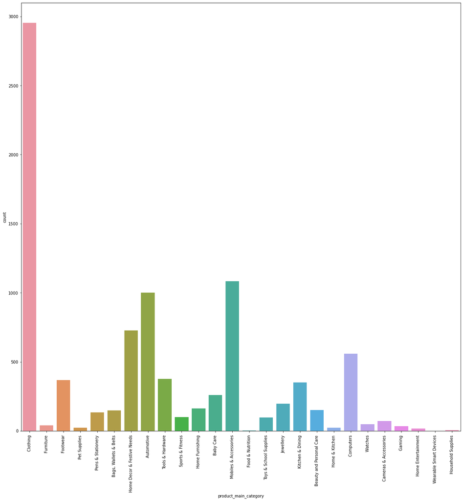

```python
plt.figure(figsize=(20,20))
sns.countplot(data=ECom_Data, x='product_main_category');
plt.xticks(rotation=90);
```

### Ans 4a) The above shown graph is the bar graph showing product main category on X-axis and the count on Y-axis. This graph was plotted using function "countplot()"

### Ans 4b)Result: From the above graph, the maximum number of orders placed for the category is Clothing and the minimum number of orders placed for the category is Wearable Smart Devices

```python
ECom_Data.sort_values('product_main_category',ascending=False).head(5)
```

|  | Customer_uniq_id | Region | Order_Date | Expected_Delivery_Date | Delivered_Date | product_name | product_main_category | product_subcategory | product_category_filter | product_category_subfilter | product_unique ID | retail_price | discounted_price | product_rating | Brand |
| --- | --- | --- | --- | --- | --- | --- | --- | --- | --- | --- | --- | --- | --- | --- | --- |
| 3546 | e9286a103f2d3dcc752c188a666825ea | South | 09-06-2021 | 12-06-2021 | 12-06-2021 | Besto LED-B3PWGYR Smart Band Strap | Wearable Smart Devices | Wearable Accessories | Besto Wearable Accessories | Besto LED-B3PWGYR Smart Band Strap (Mullti Co... | SBWEGKHH7SY6ENHV | 1299 | 539 | 3.0 | Besto |
| 3018 | 379bc81948d3f1f4b2701a0f7434e5b9 | East | 26-05-2021 | 29-05-2021 | 29-05-2021 | Italian Fashion wt276 Analog Watch - For Girl... | Watches | Wrist Watches | Italian Fashion Wrist Watches | Italian Fashion wt276 Analog Watch - For Gir... | WATEHYW2NN8YBDYZ | 999 | 549 | 4.0 | Italian Fashion |
| 2944 | 2280fc39ac93b696dc02a2ba6b128711 | East | 24-04-2021 | 27-04-2021 | 27-04-2021 | Wisdom LW0065 Analog Watch - For Women, Girls | Watches | Wrist Watches | Wisdom Wrist Watches | Wisdom LW0065 Analog Watch - For Women, Girls | WATEHYJBSKK8HHKC | 898 | 279 | 5.0 | Wisdom |
| 2939 | 5bdcb99b86cf6613a69e0a6046e44ff6 | North | 24-04-2021 | 27-04-2021 | 27-04-2021 | ESIDON AKADA04 Analog Watch - For Women | Watches | Wrist Watches | ESIDON Wrist Watches | ESIDON AKADA04 Analog Watch - For Women | WATEHVHJSUBGKZVG | 1999 | 449 | 2.0 | ESIDON |
| 2992 | 08613e8b27838b997069b1fedb6e88d2 | East | 11-04-2021 | 14-04-2021 | 14-04-2021 | V9 METAL STRAP Analog Watch - For Men | Watches | Wrist Watches | V9 Wrist Watches | V9 METAL STRAP Analog Watch - For Men | WATEHZZV8HF77B94 | 649 | 499 | 3.0 | V9 |

### In E-commerce, both the retailers (here brands) and the company have to make profit to sustain in the business. The E-Commerce company has the following rule for computing their own revenue:

```
The company charges
(i) 25% on the orders having final price (discounted price) greater than 600
(ii) 15% on the orders having final price (discounted price) greater than 350 but less than or equal to 600
(iii) 10% on the orders having final price (discounted price) greater than 100 but less than or equal to 350
(iv) Otherwise, 5% on the final price (discounted price)
```

### Q 5. Find the net revenue generated by the E-Commerce company over all orders placed.

```python
# Creating a if condition to find the E_commerce revenue
ECom_Data['E_Commerce_Revenue']= [i*0.25 if i>600 else i*0.15 if 350<i<=600 else i*0.1 if 100<i<=350 else i*0.05 for i in ECom_Data.discounted_price]
ECom_Data.filter(['retail_price', 'discounted_price', 'E_Commerce_Revenue']).head(20)
```

|  | retail_price | discounted_price | E_Commerce_Revenue |
| --- | --- | --- | --- |
| 0 | 999 | 379 | 56.85 |
| 1 | 32157 | 22646 | 5661.50 |
| 2 | 999 | 499 | 74.85 |
| 3 | 699 | 267 | 26.70 |
| 4 | 220 | 210 | 21.00 |
| 5 | 1199 | 479 | 71.85 |
| 6 | 32157 | 22646 | 5661.50 |
| 7 | 699 | 349 | 34.90 |
| 8 | 1199 | 479 | 71.85 |
| 9 | 1724 | 950 | 237.50 |
| 10 | 2299 | 910 | 227.50 |
| 11 | 300 | 256 | 25.60 |
| 12 | 999 | 379 | 56.85 |
| 13 | 699 | 699 | 174.75 |
| 14 | 999 | 379 | 56.85 |
| 15 | 32157 | 22646 | 5661.50 |
| 16 | 899 | 449 | 67.35 |
| 17 | 2499 | 999 | 249.75 |
| 18 | 32157 | 22646 | 5661.50 |
| 19 | 2400 | 1039 | 259.75 |

```python
# Net revenue generated by the Ecommerce company
Net_revenue=ECom_Data['E_Commerce_Revenue'].sum()
Net_revenue
```

```
2242221.75
```

### Ans 5) Explanation:The Net Revenue of the E-Commerce company can be calculated by applying the "if condition" and finding the revenue generated from each product by applying the companies condition and then adding all those values.

### Result: The Net revenue generated by the E-Commerce company is rupees 22,42,221.75

### Q6.Calculate the Net BrandRevenue for each Brand and list the top 14 Brand having maximum revenue in descending order

```
Hint: Net BrandRevenue is BrandRevenue which is generated after all the deductions. Also, BrandRevenue is different from the E-Commerce company's net revenue.
```

```python
Brand_grp=ECom_Data.groupby(['Brand'])
ECom_Data['product_revenue']=ECom_Data['discounted_price']-ECom_Data['E_Commerce_Revenue']
ECom_Data.head(5)
```

[output not shown]

```python
ECom_Data.filter(['retail_price', 'discounted_price', 'E_Commerce_Revenue','product_revenue']).head(5)
```

|  | retail_price | discounted_price | E_Commerce_Revenue | product_revenue |
| --- | --- | --- | --- | --- |
| 0 | 999 | 379 | 56.85 | 322.15 |
| 1 | 32157 | 22646 | 5661.50 | 16984.50 |
| 2 | 999 | 499 | 74.85 | 424.15 |
| 3 | 699 | 267 | 26.70 | 240.30 |
| 4 | 220 | 210 | 21.00 | 189.00 |

```python
Net_Brand_revenue=Brand_grp['product_revenue'].sum()
Net_Brand_revenue
```

```
Brand
1OAK             1015.40
3A AUTOCARE     55647.90
3D Mat           5249.25
3kFactory         156.60
4D               5961.00
                  ...
youniqueshop      480.00
zDelhi.com       2999.25
zaidis            116.10
zasmina           575.10
 Tarkan           314.10
Name: product_revenue, Length: 2580, dtype: float64
```

### Ans 6) Explanation: Brand_grp is a variable that was created using "groupby()" function in which data of brand was stored. Individual product revenue was calculated by subtracting the E-Commerce revenue from discounted price and then the Net revenue of each brand was calculated using individual product revenue.

### Result: Therefore the Net revenue for each brand will be as shown as above.

```python
# list of top 14 Brands having maximum revenue in descending order
Net_Brand_revenue.sort_values(ascending=False).head(14)
```

```
Brand
Allure Auto     498464.25
GAGA            237390.00
Slim            212062.60
DailyObjects    181980.00
Diviniti        143115.00
Regular         126112.35
Enthopia        123146.25
TheLostPuppy    116595.35
Asus             99241.50
Springwel        88978.50
Audeze           87219.00
Lal Haveli       74239.95
Speedwav         68560.20
FabHomeDecor     67938.00
Name: product_revenue, dtype: float64
```

### Ans 6)Result: The above list shows the top 14 Brands having maximum revenue in descending order.

### Q 7. Compare prices for each product.

```
a) Draw boxplots of retail_price & discounted_price. (3 marks)
b) Are there any outliers? (Yes/No) (1mark)
c) Create a scatterplot of retail_price (x-axis) and discounted_price (y-axis)
```

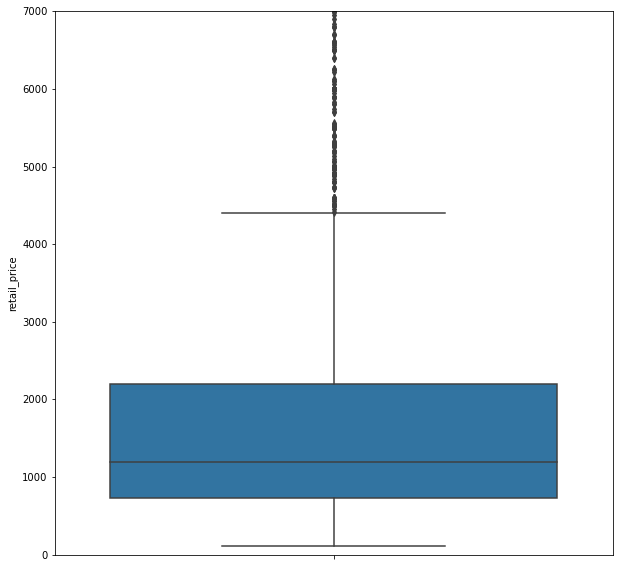

```python
plt.figure(figsize=(10,10))
plt.ylim(0,7000)
sns.boxplot(data=ECom_Data, y='retail_price');
```

##### The above box plot shows the retail price

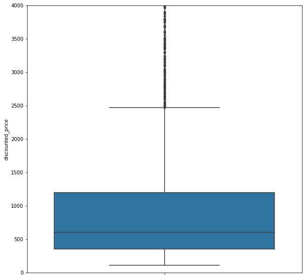

```python
plt.figure(figsize=(10,10))
plt.ylim(0,4000)
sns.boxplot(data=ECom_Data, y='discounted_price');
```

##### The above box plot shows the discounted price

### Ans 7a) The above plots are box plots of retail price and the discounted price

### Ans 7b) Yes there are outliers present for the retail price and the discounted price

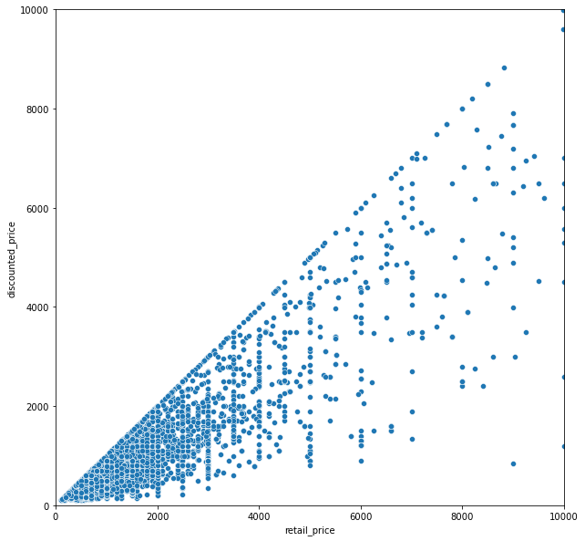

```python
plt.figure(figsize=(10,10))
plt.xlim(0,10000)
plt.ylim(0,10000)
sns.scatterplot(data=ECom_Data, x='retail_price', y='discounted_price');
```

### Ans 7c) The above scatter plot exlains that relation between retail price and the discounted price. From the graph we can conclude that the discounted price is high for the products having high retail price.

### Q 8. Create a new dataframe to include the Brand specific information as stated:

```
i. total number of orders placed per Brand
ii. total retail_price per Brand
iii. total discounted_price per Brand, and
iv. total net BrandRevenue generated per Brand.
Also, draw a pairplot using these four features.
```

```python
total_no_of_orders= ECom_Data['Brand'].value_counts()
df1=total_no_of_orders.to_frame('total_no_of_orders')
df1
```

|  | total_no_of_orders |
| --- | --- |
| Allure Auto | 469 |
| Regular | 299 |
| Slim | 267 |
| TheLostPuppy | 229 |
| Black | 147 |
| ... | ... |
| SINGHAM | 1 |
| Jack & Jones | 1 |
| Quenell | 1 |
| Shop Swipe | 1 |
| Ambika Lahenga | 1 |

2580 rows × 1 columns

### Ans 8 i) The above mentioned dataframe shows the total number of orders placed per Brand.

```python
total_retail_price=Brand_grp['retail_price'].sum()
df2=total_retail_price.to_frame('total_retail_price')
df2
```

| Brand | total_retail_price |
| --- | --- |
| 1OAK | 1698 |
| 3A AUTOCARE | 107059 |
| 3D Mat | 7250 |
| 3kFactory | 399 |
| 4D | 17500 |
| ... | ... |
| youniqueshop | 810 |
| zDelhi.com | 4499 |
| zaidis | 150 |
| zasmina | 1400 |
| Tarkan | 1999 |

2580 rows × 1 columns

### Ans 8 ii) The above dataframe shows the total retail price per brand

```python
total_discounted_price=Brand_grp['discounted_price'].sum()
df3=total_discounted_price.to_frame('total_discounted_price')
df3
```

| Brand | total_discounted_price |
| --- | --- |
| 1OAK | 1274 |
| 3A AUTOCARE | 74134 |
| 3D Mat | 6999 |
| 3kFactory | 174 |
| 4D | 7948 |
| ... | ... |
| youniqueshop | 640 |
| zDelhi.com | 3999 |
| zaidis | 129 |
| zasmina | 639 |
| Tarkan | 349 |

2580 rows × 1 columns

### Ans 8 iii) The above dataframe shows the total discounted price per brand

```python
total_net_Brand_revenue=Brand_grp['product_revenue'].sum()
df4=total_net_Brand_revenue.to_frame('total_net_Brand_revenue')
df4
```

| Brand | total_net_Brand_revenue |
| --- | --- |
| 1OAK | 1015.40 |
| 3A AUTOCARE | 55647.90 |
| 3D Mat | 5249.25 |
| 3kFactory | 156.60 |
| 4D | 5961.00 |
| ... | ... |
| youniqueshop | 480.00 |
| zDelhi.com | 2999.25 |
| zaidis | 116.10 |
| zasmina | 575.10 |
| Tarkan | 314.10 |

2580 rows × 1 columns

### Ans 8 iv) The above dataframe shows the total net brand revenue per brand

```python
Brand_specific_info=df1.append([df2, df3, df4])
Brand_specific_info
```

|  | total_no_of_orders | total_retail_price | total_discounted_price | total_net_Brand_revenue |
| --- | --- | --- | --- | --- |
| Allure Auto | 469.0 | NaN | NaN | NaN |
| Regular | 299.0 | NaN | NaN | NaN |
| Slim | 267.0 | NaN | NaN | NaN |
| TheLostPuppy | 229.0 | NaN | NaN | NaN |
| Black | 147.0 | NaN | NaN | NaN |
| ... | ... | ... | ... | ... |
| youniqueshop | NaN | NaN | NaN | 480.00 |
| zDelhi.com | NaN | NaN | NaN | 2999.25 |
| zaidis | NaN | NaN | NaN | 116.10 |
| zasmina | NaN | NaN | NaN | 575.10 |
| Tarkan | NaN | NaN | NaN | 314.10 |

10320 rows × 4 columns

[figure not shown]

```python
sns.pairplot(data=Brand_specific_info[['total_no_of_orders','total_retail_price' ,'total_discounted_price' , 'total_net_Brand_revenue']]);
```

### Q 9.Compare performance regionwise

```
a) Draw a lineplot for the monthly net Revenue of E-Commerce Company for each region separately. (4 marks)
b) Identify the best and the worst performing months for each region. (2 marks)
Note: Only those days with actual orders(Order_Date) placed are present in the dataset. Assuming there were no orders on other days
```

```python
ECom_Data.info()
```

[output not shown]

### From the above data we can say that the date is in object data type but it needs to be in date time function.

```python
# changing the data type of Order_date
ECom_Data['Order_Date']=pd.to_datetime(ECom_Data['Order_Date'], dayfirst=True)
```

```python
ECom_Data.info()
```

[output not shown]

### Therefore the Order_Date datatype was changed to "datetime"

```python
#extracting ordered_month and creating a new ordered_month column
ECom_Data['ordered_month']=ECom_Data['Order_Date'].dt.month
ECom_Data
```

[output not shown]

8927 rows × 20 columns

```python
ordered_month_region_grp=ECom_Data.groupby(['ordered_month','Region'])
monthly_net_Revenue=ordered_month_region_grp['product_revenue'].sum()
Monthly_net_Revenue=monthly_net_Revenue.to_frame('monthly_net_Revenue')
Monthly_net_Revenue
```

| ordered_month | Region | monthly_net_Revenue |
| --- | --- | --- |
| 1 | East | 759841.40 |
|  | North | 354509.90 |
|  | South | 174278.20 |
|  | West | 520664.25 |
| 2 | East | 49384.75 |
|  | North | 23782.65 |
|  | South | 16718.15 |
|  | West | 49839.10 |
| 3 | East | 412294.90 |
|  | North | 142376.05 |
|  | South | 198913.85 |
|  | West | 391152.50 |
| 4 | East | 195066.95 |
|  | North | 100680.65 |
|  | South | 63081.90 |
|  | West | 160567.80 |
| 5 | East | 87312.50 |
|  | North | 46680.50 |
|  | South | 15544.25 |
|  | West | 66607.15 |
| 6 | East | 191678.40 |
|  | North | 106239.65 |
|  | South | 65766.25 |
|  | West | 146556.20 |
| 7 | East | 1391.65 |
|  | North | 1364.00 |
|  | West | 1701.00 |
| 8 | East | 2474.25 |
|  | North | 1124.25 |
|  | West | 2210.25 |
| 9 | East | 2378.85 |
| 10 | East | 771.75 |
|  | West | 875.25 |
| 12 | East | 1242728.15 |
|  | North | 652792.45 |
|  | South | 326987.75 |
|  | West | 1022725.75 |

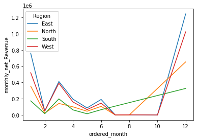

```python
sns.lineplot(data=Monthly_net_Revenue, x='ordered_month', y='monthly_net_Revenue',hue='Region',ci=False);
```

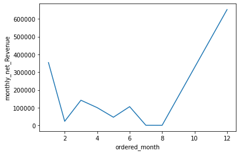

```python
North_region = Monthly_net_Revenue.query("Region == 'North'")
sns.lineplot(data=North_region, x='ordered_month', y='monthly_net_Revenue');
```

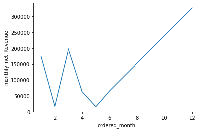

```python
South_region = Monthly_net_Revenue.query("Region == 'South'")
sns.lineplot(data=South_region, x='ordered_month', y='monthly_net_Revenue');
```

[figure not shown]

```python
East_region = Monthly_net_Revenue.query("Region == 'East'")
sns.lineplot(data=East_region, x='ordered_month', y='monthly_net_Revenue');
```

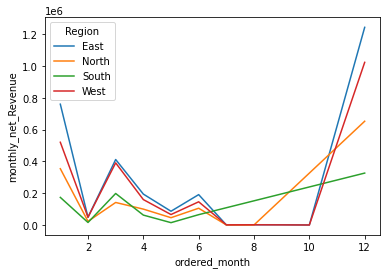

```python
sns.lineplot(data=Monthly_net_Revenue, x='ordered_month', y='monthly_net_Revenue',hue='Region',ci=False);
```

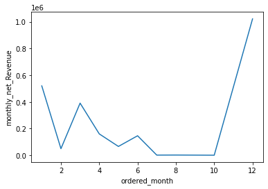

```python
West_region = Monthly_net_Revenue.query("Region == 'West'")
sns.lineplot(data=West_region, x='ordered_month', y='monthly_net_Revenue');
```

```python
%notebook "C:\Users\shiva\OneDrive\Desktop\SHIVAKUMAR_VASUPILLI_21-AUG-2022.ipynb"
```